# Project overview

Clementine

2023-02-28

# Questions

How did recruitment dynamics changed in the Quebec boreal forest between the periods 1970-1981 and 2005-2018 ?

- In term of presence and density
- For the common species
- How did perturbation influenced those changes
- What is the effect of other parameters (biotic or abiotic)

*further question :*

- *Growth from saplings to trees*
- *What does it means for the future of the boreal forest ?*
- *Ecosystem shifts ?*

To keep in mind for my report : **Ecosystem functionning**

# Method

## Data

All the data from saplings Biologic parameters from tree_data Perturbation from pep_ori

- 2 time periodes : 1970-1981 and 2005-2018 (to be confirmed)
- Species : Sapin baumier, erable rouge, erable à sucre, bouleau jaune, bouleau à papier, epinette noire (beginning with sapin baumier and erable rouge to make the model)
- Zone : All (to be confirmed)
- Other selections :
  - ph, epmatorg et cl_drai connues (au moins une fois pour la placette)
  - pas de plantation
  - date de perturbation connues

*Would be interesting to think about including seedlings*

## Model

Indépendant pour chaque espèces

### Abiotic

- ph_humus
- organic matter thickness
- soil drainage ?
- topographique ? (pente, altitude, exposition)

#### Biotic

- Basal area of the Species
- Total basal area
- Couvert ? (I don’t know if I have enough data)
- Species richness could be interesting

Perhaps there are better ways to represent the adult population

### Geographic

- Latitude
- Longitude

### Perturbation

- Type of disturbance
- Time since disturbance

### Effect of the periode

On :

- the intercept
- the coef for latitude

I assume that the effect of botic and abiotic parameters on recruitment are the same for the 2 periodes (no evolution)

## Model

Two part hurdle model : - First part : presence or absence of the species saplings
$$PA_i =
\mathcal{B}(p_i)$$
- Second part : density of saplings
$$NB_i = \mathcal{P}(\lambda_i *
presence_i)$$

Avec (a completer avec les autres paramètres qui m’interessent):

$$logit(p_i) = Intercept_{t} + \alpha_{t}
* latitude_i +
\gamma_{disturbance_i} + \gamma'_{disturbance_i} * TSD_i +
\beta_1 * ph_i + \beta_2 * epmatorg_i + \beta_4 * longitude_i +
\delta_{cl.drai_i}$$

$$log(\lambda_i) = Intercept_{t} +
\alpha_{t} * latitude_i +
\gamma_{disturbance_i} + \gamma'_{disturbance_i} * TSD_i +
\beta_1 * ph_i + \beta_2 * epmatorg_i + \beta_4 * longitude_i +
\delta_{cl.drai_i}$$

**Note** : different coef for lambda and p

In consideration :

- There might be parameters to add to the square knowing that the relation is not linear (example ph, TSD)
- Living things don’t only have linear or even polynomial relations, there are also limits (of ph for example simply for survival)
- Interaction between parameters

# Results exemple

With reduced data for the exemple :

- random sample of 1000 lines
- For ERR (erable rouge)
- 1 type of disturbance only : logging (all other pe are concidered as not disturbed)

**Note** : I need to truncate the Poisson law but I have a problem with it

## Model code

```r
model_pert <- function(){
    # likelihood
    for(i in 1:N){
        pa[i] ~ dbern(p[i])
        nb[i] ~ dpois(pa[i] * lambda[i]) # T(0,)

        logit(p[i]) <-
            intercept_pa[t[i]] +
            lat_pa[t[i]] * latitude[i] +
            lon_pa * longitude[i] +
            ph_pa * ph_humus [i] +
            ph_pa2 * (ph_humus [i])**2 +
            epm_pa * epmatorg[i] +
            beta * is_logging[i] +
            gamma * TSlogging[i]
        log(lambda[i]) <-
            intercept_nb[t[i]] +
            lat_nb[t[i]] * latitude[i] +
            lon_nb * longitude[i] +
            ph_nb * ph_humus [i] +
            ph_nb2 * (ph_humus [i])**2 +
            epm_nb * epmatorg[i]
        }

    # priors
    for (t in 1:2){
        intercept_pa[t] ~ dunif(-10, 10)
        lat_pa[t] ~ dunif(-10, 10)
        intercept_nb[t] ~ dunif(-10, 10)
        lat_nb[t] ~ dunif(-10, 10)
    }
    lon_pa ~ dunif(-10, 10)
    ph_pa ~ dunif(-10, 10)
    epm_pa ~ dunif(-10, 10)
    lon_nb ~ dunif(-10, 10)
    ph_nb ~ dunif(-10, 10)
    epm_nb ~ dunif(-10, 10)
    ph_nb2 ~ dunif(-10, 10)
    ph_pa2 ~ dunif(-10, 10)
    beta ~ dunif(-10, 10)
    gamma ~ dunif(-1, 1)
}
```

## Model output

```r
print(runtime)
```

```
## Time difference of 5.791056 mins
```

```r
print(out_model)
```

```
## Inference for Bugs model at "C:/Users/CLEMEN~1/AppData/Local/Temp/RtmpkxsPwR/model729c28742788.txt", fit using jags,
##  3 chains, each with 10000 iterations (first 1000 discarded)
##  n.sims = 27000 iterations saved
##                  mu.vect sd.vect     2.5%      25%      50%      75%    97.5%
## beta               0.176   0.625   -1.080   -0.241    0.179    0.605    1.368
## epm_nb            -0.372   0.154   -0.681   -0.474   -0.370   -0.269   -0.072
## epm_pa            -1.272   0.335   -1.955   -1.492   -1.263   -1.040   -0.649
## gamma             -0.014   0.026   -0.065   -0.032   -0.014    0.003    0.035
## intercept_nb[1]    1.021   0.175    0.671    0.902    1.023    1.142    1.355
## intercept_nb[2]    1.714   0.091    1.535    1.654    1.713    1.774    1.891
## intercept_pa[1]   -3.152   0.336   -3.851   -3.372   -3.134   -2.918   -2.539
## intercept_pa[2]   -2.199   0.198   -2.601   -2.329   -2.194   -2.062   -1.820
## lat_nb[1]         -0.639   0.188   -1.013   -0.764   -0.636   -0.511   -0.272
## lat_nb[2]          0.078   0.090   -0.097    0.017    0.078    0.140    0.254
## lat_pa[1]         -1.381   0.372   -2.144   -1.623   -1.368   -1.125   -0.691
## lat_pa[2]         -1.008   0.196   -1.403   -1.137   -1.003   -0.874   -0.632
## lon_nb             0.080   0.047   -0.013    0.048    0.080    0.112    0.172
## lon_pa            -0.317   0.136   -0.589   -0.407   -0.316   -0.227   -0.052
## ph_nb              0.017   0.082   -0.144   -0.039    0.017    0.072    0.178
## ph_nb2            -0.084   0.045   -0.176   -0.114   -0.083   -0.053   -0.001
## ph_pa             -0.288   0.196   -0.668   -0.420   -0.289   -0.154    0.096
## ph_pa2            -0.057   0.080   -0.225   -0.108   -0.054   -0.003    0.090
## deviance        2068.017   6.046 2058.166 2063.690 2067.377 2071.590 2081.745
##                  Rhat n.eff
## beta            1.001 23000
## epm_nb          1.001  4800
## epm_pa          1.001  4300
## gamma           1.001 27000
## intercept_nb[1] 1.003  1100
## intercept_nb[2] 1.002  1500
## intercept_pa[1] 1.002  1400
## intercept_pa[2] 1.001  5100
## lat_nb[1]       1.003  1200
## lat_nb[2]       1.002  1400
## lat_pa[1]       1.002  1900
## lat_pa[2]       1.001  6500
## lon_nb          1.002  2200
## lon_pa          1.001 27000
## ph_nb           1.002  1300
## ph_nb2          1.002  2900
## ph_pa           1.002  2400
## ph_pa2          1.002  3300
## deviance        1.001 27000
##
## For each parameter, n.eff is a crude measure of effective sample size,
## and Rhat is the potential scale reduction factor (at convergence, Rhat=1).
##
## DIC info (using the rule, pD = var(deviance)/2)
## pD = 18.3 and DIC = 2086.3
## DIC is an estimate of expected predictive error (lower deviance is better).
```

## Parameters output

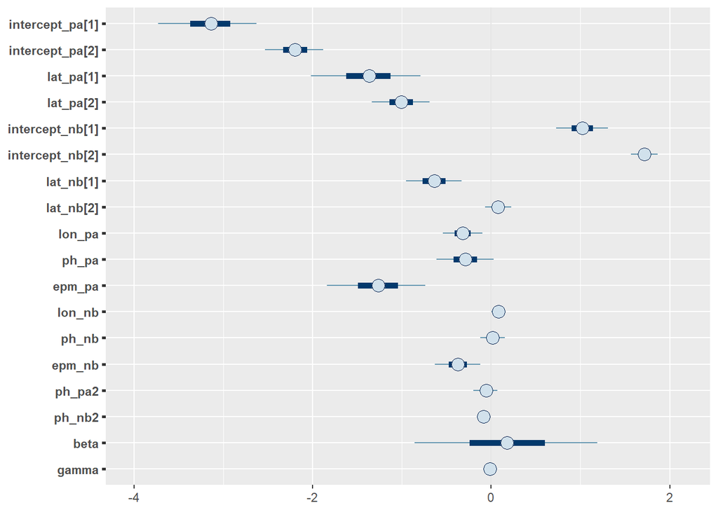

```r
mcmc_intervals(as.mcmc(out_model),
    pars = c("intercept_pa[1]", "intercept_pa[2]", "lat_pa[1]", "lat_pa[2]",
        "intercept_nb[1]", "intercept_nb[2]", "lat_nb[1]", "lat_nb[2]",
        "lon_pa", "ph_pa", "epm_pa", "lon_nb", "ph_nb", "epm_nb",
        "ph_pa2", "ph_nb2", "beta", "gamma"))
```

**Note** : autoceralation and convergence are great

**Note** : priors may not be very good